# **Logistic regression**

*This week I did a logistic regression using Rscript to wrangle the data and RMarkdown for the analysis.*

```r
date()
```

```
## [1] "Mon Nov 22 16:11:22 2021"
```

```r
alc <- read.csv(file = "C:/LocalData/inkaronk/IODS-project/joindata.csv", header = TRUE)
```

## About this dataset

This data was collected in 2008 from two Portuguese schools using questionnaires and school reports. It has information about student performance and students’ alcohol consumption.

## Hypotheses

Today we will use this data to see if there are any relationships between high/low alcohol consumption and sex, age, number of past class failures and/or the information about participant’s romantic relationship status. My hypothesis is that age and failures have positive correlations with high use, but there aren’t significant relationship with alcohol consumption and sex and relationship status.

## Chosen variables and their relationship with alcohol consumption

As I mentioned, I chose sex, age, failures and relationship as my variables that I want to compare with alcohol consumption. Here you can see numerical and graphical distributions of these variables.

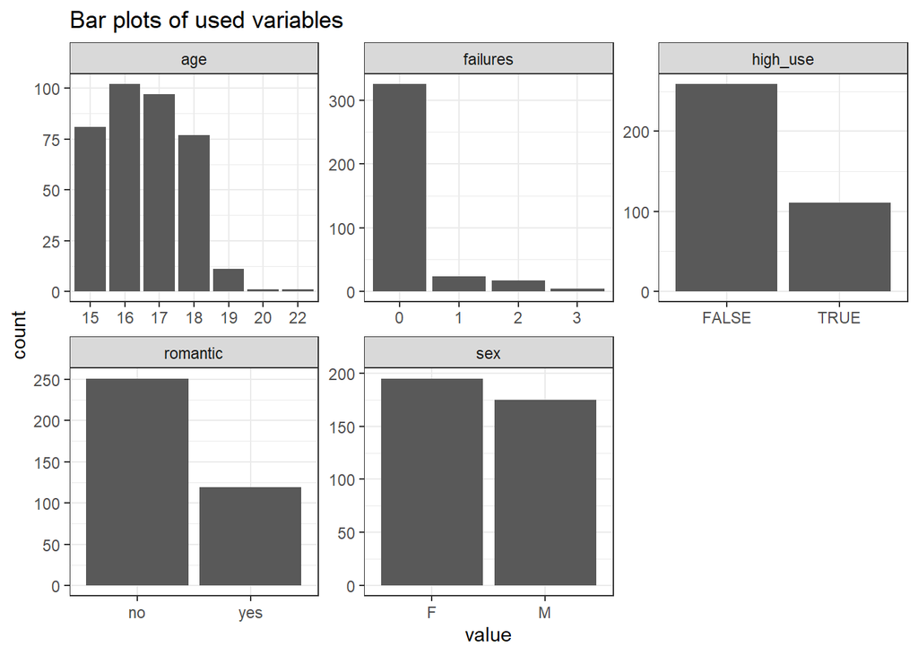

```r
library(ggplot2)
library(tidyr)
library(dplyr)
options(scipen = 999)
theme_set(theme_bw())

newdata <- select(alc, "high_use", "sex", "age", "failures", "romantic")
gather(newdata) %>% ggplot(aes(value)) + facet_wrap("key", scales = "free") + geom_bar() + labs(title = "Bar plots of used variables")
```

This table shows distributions of the used variables. Most of the participants are 15-18 years old, but there are also 19-22 year old students. Most of the students have not past class failures. Majority uses alcohol less than twice a week (high_use is false). One third of the participants is in a romantic relationship. Distributions between female and male do not vary.

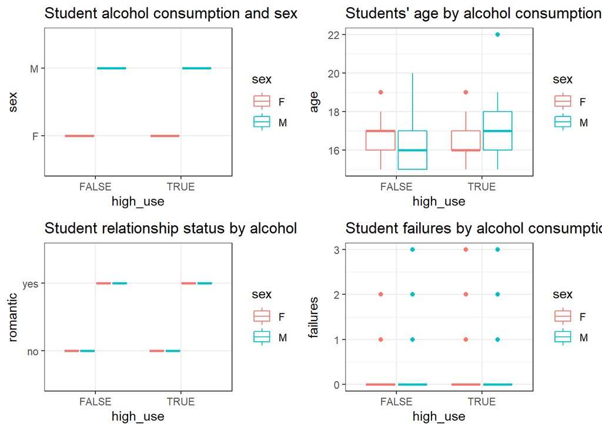

```r
library(ggplot2)
library(cowplot)

g1 <- ggplot(alc, aes(x = high_use, y = sex, col = sex)) + geom_boxplot() + ggtitle("Student alcohol consumption and sex")
g2 <- ggplot(alc, aes(x = high_use, y = age, col = sex)) + geom_boxplot() + ggtitle("Students' age by alcohol consumption and sex")
g3 <- ggplot(alc, aes(x = high_use, y = romantic, col = sex)) + geom_boxplot() + ggtitle("Student relationship status by alcohol consumption and sex")
g4 <- ggplot(alc, aes(x = high_use, y = failures, col = sex)) + geom_boxplot() + ggtitle("Student failures by alcohol consumption and sex")

gall <- plot_grid(g1, g2, g3, g4,
  align="hv"
)
gall
```

```r
library(sjPlot)
tab_xtab(var.row = alc$high_use, var.col = alc$sex)
```

| high_use | sex |  | Total |  |
| --- | --- | --- | --- | --- |
|  | F | M |  |  |
| FALSE | 154 | 105 |  | 259 |
| TRUE | 41 | 70 | 111 |  |
| Total | 195 | 175 | 370 |  |

```r
tab_xtab(var.row = alc$high_use, var.col = alc$age)
```

| high_use | age |  |  |  |  |  |  | Total |  |
| --- | --- | --- | --- | --- | --- | --- | --- | --- | --- |
|  | 15 | 16 | 17 | 18 | 19 | 20 | 22 |  |  |
| FALSE | 63 | 74 | 62 | 52 | 7 | 1 | 0 |  | 259 |
| TRUE | 18 | 28 | 35 | 25 | 4 | 0 | 1 | 111 |  |
| Total | 81 | 102 | 97 | 77 | 11 | 1 | 1 | 370 |  |

```r
tab_xtab(var.row = alc$high_use, var.col = alc$romantic)
```

| high_use | romantic |  | Total |  |
| --- | --- | --- | --- | --- |
|  | no | yes |  |  |
| FALSE | 173 | 86 |  | 259 |
| TRUE | 78 | 33 | 111 |  |
| Total | 251 | 119 | 370 |  |

```r
tab_xtab(var.row = alc$high_use, var.col = alc$failures)
```

| high_use | failures |  |  |  | Total |  |
| --- | --- | --- | --- | --- | --- | --- |
|  | 0 | 1 | 2 | 3 |  |  |
| FALSE | 238 | 12 | 8 | 1 |  | 259 |
| TRUE | 87 | 12 | 9 | 3 | 111 |  |
| Total | 325 | 24 | 17 | 4 | 370 |  |

## Logistic regression

Now we will do a logistic regression to statistically explore the relationship between the chosen variables and the binary high/low alcohol consumption variable as the target variable.

Sex and romantic relationship status are factor variables, so we need to modify the code.

```r
alc$sex = as.factor(alc$sex)
alc$romantic = as.factor(alc$romantic)
p <- glm(high_use ~ sex - 1 + age + romantic + failures, data = alc, family = "binomial")

summary(p)
```

```
##
## Call:
## glm(formula = high_use ~ sex - 1 + age + romantic + failures,
##     family = "binomial", data = alc)
##
## Deviance Residuals:
##     Min       1Q   Median       3Q      Max
## -1.7710  -0.8794  -0.6448   1.2924   1.9803
##
## Coefficients:
##             Estimate Std. Error z value Pr(>|z|)
## sexF         -4.0480     1.7045  -2.375   0.0176 *
## sexM         -3.1720     1.6927  -1.874   0.0609 .
## age           0.1614     0.1024   1.576   0.1150
## romanticyes  -0.1825     0.2593  -0.704   0.4816
## failures      0.5874     0.2088   2.813   0.0049 **
## ---
## Signif. codes:  0 '***' 0.001 '**' 0.01 '*' 0.05 '.' 0.1 ' ' 1
##
## (Dispersion parameter for binomial family taken to be 1)
##
##     Null deviance: 512.93  on 370  degrees of freedom
## Residual deviance: 422.99  on 365  degrees of freedom
## AIC: 432.99
##
## Number of Fisher Scoring iterations: 4
```

## Odds ratios and confedence intervals

We will now explore the predictive power of the model. We will look at the variables that were statistically significant, sex and failures.

```r
alc$sex = as.factor(alc$sex)
p2 <- glm(high_use ~ sex - 1 + failures, data = alc, family = "binomial")

OR <- coef(p2) %>% exp
CI <- confint(p2) %>% exp
cbind(OR, CI)
```

```
##                 OR     2.5 %    97.5 %
## sexF     0.2378985 0.1642397 0.3362238
## sexM     0.5712620 0.4122237 0.7847273
## failures 1.8885234 1.2799408 2.8565099
```

Results show that if the participant is male, the odds for high use of alcohol is increasing. The table also shows that if the failures are increasing, also the odds for higher alcohol consumption is increasing.

## Predictive power of the model

```r
p2 <- glm(high_use ~ sex - 1 + failures , data = alc, family = "binomial")
probabilities <- predict(p2, type = "response")
alc <- mutate(alc, probability = probabilities)
alc <- mutate(alc, prediction = probability > 0.5)
select(alc, sex, failures, high_use, probability, prediction) %>% tail(10)
```

```
##     sex failures high_use probability prediction
## 361   M        1     TRUE   0.5189629       TRUE
## 362   M        0     TRUE   0.3635689      FALSE
## 363   M        0     TRUE   0.3635689      FALSE
## 364   M        0     TRUE   0.3635689      FALSE
## 365   M        0    FALSE   0.3635689      FALSE
## 366   M        0     TRUE   0.3635689      FALSE
## 367   M        0    FALSE   0.3635689      FALSE
## 368   M        1     TRUE   0.5189629       TRUE
## 369   M        2     TRUE   0.6707730       TRUE
## 370   M        1    FALSE   0.5189629       TRUE
```

```r
table(high_use = alc$high_use, prediction = alc$prediction)
```

```
##         prediction
## high_use FALSE TRUE
##    FALSE   250    9
##    TRUE     95   16
```

Here you can see 2x2 cross tabulation of predictions versus the actual values.